# Create Dataset

# Model

#After arranging our data, it was time to create a model, first we determined the train data and then we tested these data.

# 1) Inflation - Unemployment

> Datasets

```r
train_data = data %>% filter(Year >= 1960, Year <= 2005)
test_data = data %>% filter(Year > 2005, Year <= 2020)
```

> Random Forest:

> Random Forest is a commonly-used machine learning algorithm which combines the output of multiple decision trees to reach a single result. Its ease of use and flexibility have fueled its adoption, as it handles both classification and regression problems.

> #The first method we used was random forest. This is because random forest can measure the importance of each variable and combines multiple decision trees to form a prediction model.

```r
library(randomForest)
rf_model = randomForest(Inflation_Rate ~ Unemployment_Rate, data=train_data)
summary(rf_model)
```

```
##                 Length Class  Mode
## call              3    -none- call
## type              1    -none- character
## predicted        46    -none- numeric
## mse             500    -none- numeric
## rsq             500    -none- numeric
## oob.times        46    -none- numeric
## importance        1    -none- numeric
## importanceSD      0    -none- NULL
## localImportance   0    -none- NULL
## proximity         0    -none- NULL
## ntree             1    -none- numeric
## mtry              1    -none- numeric
## forest           11    -none- list
## coefs             0    -none- NULL
## y                46    -none- numeric
## test              0    -none- NULL
## inbag             0    -none- NULL
## terms             3    terms  call
```

> Linear Regression

> Linear regression analysis is used to predict the value of a variable based on the value of another variable. The variable you want to predict is called the dependent variable. The variable you are using to predict the other variable’s value is called the independent variable.

> The second method we used was Linear regression, because we thought it would help us to understand the relationship between variables.

```r
lr_model <- lm(Inflation_Rate ~ Unemployment_Rate, data=train_data)
summary(lr_model)
```

```
##
## Call:
## lm(formula = Inflation_Rate ~ Unemployment_Rate, data = train_data)
##
## Residuals:
##     Min      1Q  Median      3Q     Max
## -3.3302 -1.7177 -0.6994  0.9308  8.1807
##
## Coefficients:
##                   Estimate Std. Error t value Pr(>|t|)
## (Intercept)        -0.5555     1.6346  -0.340    0.736
## Unemployment_Rate   0.8160     0.2686   3.038    0.004 **
## ---
## Signif. codes:  0 '***' 0.001 '**' 0.01 '*' 0.05 '.' 0.1 ' ' 1
##
## Residual standard error: 2.671 on 44 degrees of freedom
## Multiple R-squared:  0.1734, Adjusted R-squared:  0.1546
## F-statistic: 9.228 on 1 and 44 DF,  p-value: 0.003998
```

> After training the data, it was time to predict.

```r
results_df <- data.frame(
  Year =numeric(),
  Actual_Unemployment = numeric(),
  Regression_Predict = numeric(),
  RandomForest_Predict= numeric()
)

pre_rf = predict(rf_model, newdata = data.frame(Unemployment_Rate=test_data$Unemployment_Rate))
pre_lr = predict(lr_model, newdata = data.frame(Unemployment_Rate=test_data$Unemployment_Rate))

result = data.frame(Year=test_data$Year,Actual_Inflation_Rate=test_data$Inflation_Rate,RF_Predict_Rate=pre_rf,LR_Predict_Rate=pre_lr)


result$RF_Err = result$RF_Predict_Rate - result$Actual_Inflation_Rate
result$LR_Err = result$LR_Predict_Rate - result$Actual_Inflation_Rate


head(result,10)
```

```
##    Year Actual_Inflation_Rate RF_Predict_Rate LR_Predict_Rate     RF_Err
## 1  2006                  3.23        2.038819        3.034660 -1.1911805
## 2  2007                  2.85        2.607488        3.524233 -0.2425124
## 3  2008                  3.84        5.322238        5.400928  1.4822377
## 4  2009                 -0.36        7.441127        7.522410  7.8011267
## 5  2010                  1.64        7.575990        7.032837  5.9359897
## 6  2011                  3.16        7.572266        6.380073  4.4122657
## 7  2012                  2.07        5.865096        5.890501  3.7950960
## 8  2013                  1.46        2.618222        4.911355  1.1582217
## 9  2014                  1.62        2.411867        4.013805  0.7918673
## 10 2015                  0.12        2.607488        3.524233  2.4874876
##        LR_Err
## 1  -0.1953402
## 2   0.6742325
## 3   1.5609279
## 4   7.8824096
## 5   5.3928369
## 6   3.2200733
## 7   3.8205006
## 8   3.4513552
## 9   2.3938052
## 10  3.4042325
```

### Mean Squared Error

```r
rf_mse_1 = mean(result$RF_Err^2)
cat("Random Forest MSE", rf_mse_1, "\n")
```

```
## Random Forest MSE 10.26008
```

```r
lr_mse_1 = mean(result$LR_Err^2)
cat("Linear Regression MSE", lr_mse_1, "\n")
```

```
## Linear Regression MSE 11.12079
```

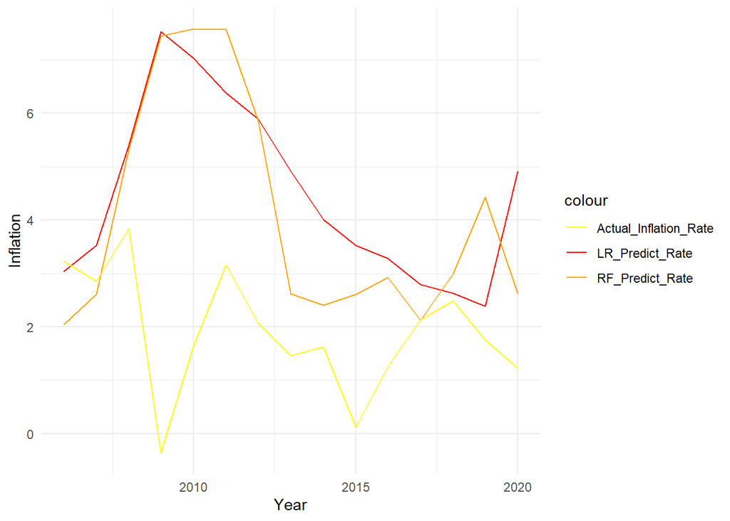

```r
ggplot(data = result) +
  geom_line(aes(x = Year, y = LR_Predict_Rate, color = "LR_Predict_Rate")) +
  geom_line(aes(x = Year, y = RF_Predict_Rate, color = "RF_Predict_Rate")) +
  geom_line(aes(x = Year, y = Actual_Inflation_Rate, color = "Actual_Inflation_Rate")) +
  labs(x = "Year", y = "Inflation") +
  scale_color_manual(values = c("LR_Predict_Rate" = "red", "RF_Predict_Rate"="orange","Actual_Inflation_Rate" = "yellow")) +
  theme_minimal()
```

## 2) Inflation Rate - Interest Rate

```r
lr_model <- lm(Inflation_Rate ~ Interest_Rates, data=na.omit(train_data))
summary(lr_model)
```

```
##
## Call:
## lm(formula = Inflation_Rate ~ Interest_Rates, data = na.omit(train_data))
##
## Residuals:
##     Min      1Q  Median      3Q     Max
## -3.0989 -1.1437 -0.3134  0.8280  5.0722
##
## Coefficients:
##                Estimate Std. Error t value Pr(>|t|)
## (Intercept)     0.05131    0.59497   0.086    0.932
## Interest_Rates  0.68841    0.08609   7.996 4.08e-10 ***
## ---
## Signif. codes:  0 '***' 0.001 '**' 0.01 '*' 0.05 '.' 0.1 ' ' 1
##
## Residual standard error: 1.875 on 44 degrees of freedom
## Multiple R-squared:  0.5924, Adjusted R-squared:  0.5831
## F-statistic: 63.94 on 1 and 44 DF,  p-value: 4.082e-10
```

```r
rf_model <- randomForest(Inflation_Rate ~ Interest_Rates, data=train_data)
summary(rf_model)
```

```
##                 Length Class  Mode
## call              3    -none- call
## type              1    -none- character
## predicted        46    -none- numeric
## mse             500    -none- numeric
## rsq             500    -none- numeric
## oob.times        46    -none- numeric
## importance        1    -none- numeric
## importanceSD      0    -none- NULL
## localImportance   0    -none- NULL
## proximity         0    -none- NULL
## ntree             1    -none- numeric
## mtry              1    -none- numeric
## forest           11    -none- list
## coefs             0    -none- NULL
## y                46    -none- numeric
## test              0    -none- NULL
## inbag             0    -none- NULL
## terms             3    terms  call
```

```r
results_df <- data.frame(
  Year =numeric(),
  Actual_Inflation_Rate = numeric(),
  Regression_Predict = numeric(),
  RF_Predict= numeric()
)

pre_lr = predict(lr_model, newdata = data.frame(Interest_Rates=test_data$Interest_Rates))
pre_rf = predict(rf_model, newdata = data.frame(Interest_Rates=test_data$Interest_Rates))

result = data.frame(Year=test_data$Year,Actual_Inflation_Rate=test_data$Inflation_Rate,LR_Predict_Rate=pre_lr,RF_Predict_Rate=pre_rf)


result$LR_Err = result$LR_Predict_Rate - result$Actual_Inflation_Rate
result$RF_Err = result$RF_Predict_Rate - result$Actual_Inflation_Rate


head(result,10)
```

```
##    Year Actual_Inflation_Rate LR_Predict_Rate RF_Predict_Rate      LR_Err
## 1  2006                  3.23       3.4726936        3.132133  0.24269365
## 2  2007                  2.85       3.5071140        4.072742  0.65711401
## 3  2008                  3.84       1.3730515        1.484437 -2.46694851
## 4  2009                 -0.36       0.1614547        2.180642  0.52145470
## 5  2010                  1.64       0.1752228        2.180642 -1.46477715
## 6  2011                  3.16       0.1201503        2.180642 -3.03984973
## 7  2012                  2.07       0.1476866        2.180642 -1.92231344
## 8  2013                  1.46       0.1270343        2.180642 -1.33296566
## 9  2014                  1.62       0.1132662        2.180642 -1.50673381
## 10 2015                  0.12       0.1408025        2.180642  0.02080249
##         RF_Err
## 1  -0.09786733
## 2   1.22274200
## 3  -2.35556333
## 4   2.54064233
## 5   0.54064233
## 6  -0.97935767
## 7   0.11064233
## 8   0.72064233
## 9   0.56064233
## 10  2.06064233
```

```r
lr_mse_2 = mean(result$LR_Err^2)
cat("Linear Regression MSE", lr_mse_2, "\n")
```

```
## Linear Regression MSE 2.077702
```

```r
rf_mse_2 = mean(result$RF_Err^2)
cat("RF MSE", rf_mse_2, "\n")
```

```
## RF MSE 1.505035
```

We re-graphed our predictions.

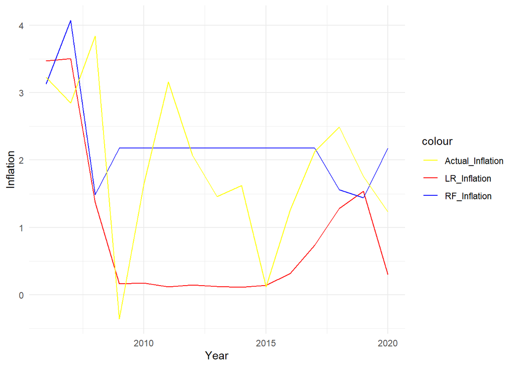

```r
ggplot(data = result) +
  geom_line(aes(x = Year, y = LR_Predict_Rate, color = "LR_Inflation")) +
  geom_line(aes(x = Year, y = RF_Predict_Rate, color = "RF_Inflation")) +
  geom_line(aes(x = Year, y = Actual_Inflation_Rate, color = "Actual_Inflation")) +
  labs(x = "Year", y = "Inflation") +
  scale_color_manual(values = c("LR_Inflation" = "red", "RF_Inflation"="blue","Actual_Inflation" = "yellow")) +
  theme_minimal()
```

# 3) 4lü

```r
lr_model <- lm(Inflation_Rate ~ Unemployment_Rate + S_P_500 + Oil._Price + Interest_Rates, data=train_data)
summary(lr_model)
```

```
##
## Call:
## lm(formula = Inflation_Rate ~ Unemployment_Rate + S_P_500 + Oil._Price +
##     Interest_Rates, data = train_data)
##
## Residuals:
##     Min      1Q  Median      3Q     Max
## -3.6330 -1.0397  0.0354  0.7510  4.8403
##
## Coefficients:
##                    Estimate Std. Error t value Pr(>|t|)
## (Intercept)        0.712456   1.650902   0.432    0.668
## Unemployment_Rate -0.012169   0.263399  -0.046    0.963
## S_P_500           -0.001583   0.001224  -1.293    0.203
## Oil._Price         0.045878   0.039874   1.151    0.257
## Interest_Rates     0.564329   0.117066   4.821 1.99e-05 ***
## ---
## Signif. codes:  0 '***' 0.001 '**' 0.01 '*' 0.05 '.' 0.1 ' ' 1
##
## Residual standard error: 1.886 on 41 degrees of freedom
## Multiple R-squared:  0.6158, Adjusted R-squared:  0.5783
## F-statistic: 16.43 on 4 and 41 DF,  p-value: 4.152e-08
```

```r
rf_model <- randomForest(Inflation_Rate ~ Unemployment_Rate + S_P_500 + Oil._Price + Interest_Rates, data=train_data)
summary(rf_model)
```

```
##                 Length Class  Mode
## call              3    -none- call
## type              1    -none- character
## predicted        46    -none- numeric
## mse             500    -none- numeric
## rsq             500    -none- numeric
## oob.times        46    -none- numeric
## importance        4    -none- numeric
## importanceSD      0    -none- NULL
## localImportance   0    -none- NULL
## proximity         0    -none- NULL
## ntree             1    -none- numeric
## mtry              1    -none- numeric
## forest           11    -none- list
## coefs             0    -none- NULL
## y                46    -none- numeric
## test              0    -none- NULL
## inbag             0    -none- NULL
## terms             3    terms  call
```

```r
results_df <- data.frame(
  Year =numeric(),
  Actual_Inflation_Rate = numeric(),
  Regression_Predict = numeric(),
  RF_Predict= numeric()
)

pre_lr = predict(lr_model, newdata = data.frame(Unemployment_Rate=test_data$Unemployment_Rate,S_P_500=test_data$S_P_500,Oil._Price=test_data$Oil._Price,Interest_Rates=test_data$Interest_Rates))

pre_rf = predict(rf_model, newdata = data.frame(Unemployment_Rate=test_data$Unemployment_Rate,S_P_500=test_data$S_P_500,Oil._Price=test_data$Oil._Price,Interest_Rates=test_data$Interest_Rates))

result = data.frame(Year=test_data$Year,Actual_Inflation_Rate=test_data$Inflation_Rate,LR_Predict_Rate=pre_lr,RF_Predict_Rate=pre_rf)


result$LR_Err = result$LR_Predict_Rate - result$Actual_Inflation_Rate
result$RF_Err = result$RF_Predict_Rate - result$Actual_Inflation_Rate


head(result,10)
```

```
##    Year Actual_Inflation_Rate LR_Predict_Rate RF_Predict_Rate     LR_Err
## 1  2006                  3.23       4.3782606        3.520679  1.1482606
## 2  2007                  2.85       4.4679488        3.730656  1.6179488
## 3  2008                  3.84       4.2384794        4.613287  0.3984794
## 4  2009                 -0.36       2.0112484        4.880380  2.3712484
## 5  2010                  1.64       2.5441230        4.905136  0.9041230
## 6  2011                  3.16       3.7637658        4.938319  0.6037658
## 7  2012                  2.07       3.6352502        4.766719  1.5652502
## 8  2013                  1.46       3.0767295        4.077863  1.6167295
## 9  2014                  1.62       2.1791507        3.552437  0.5591507
## 10 2015                  0.12      -0.1364499        3.581379 -0.2564499
##       RF_Err
## 1  0.2906793
## 2  0.8806560
## 3  0.7732867
## 4  5.2403797
## 5  3.2651363
## 6  1.7783193
## 7  2.6967190
## 8  2.6178627
## 9  1.9324369
## 10 3.4613792
```

```r
lr_mse_3 = mean(result$LR_Err^2)
cat("Linear Regression MSE", lr_mse_3, "\n")
```

```
## Linear Regression MSE 2.871658
```

```r
rf_mse_3 = mean(result$RF_Err^2)
cat("RF MSE", rf_mse_3, "\n")
```

```
## RF MSE 6.122257
```

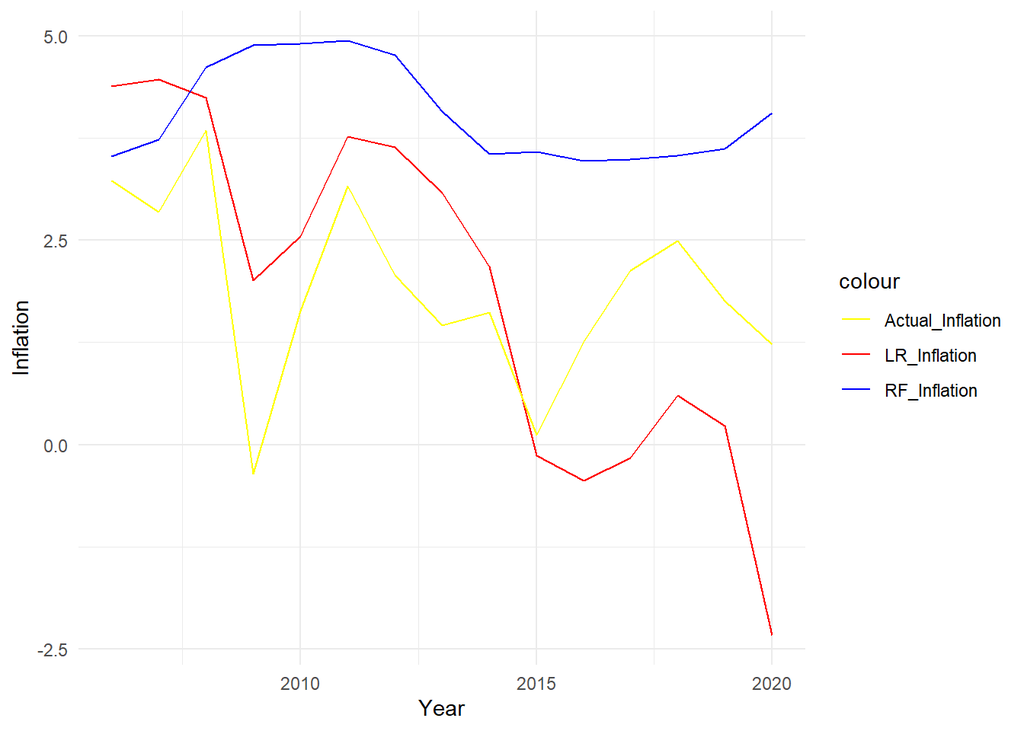

```r
ggplot(data = result) +
  geom_line(aes(x = Year, y = LR_Predict_Rate, color = "LR_Inflation")) +
  geom_line(aes(x = Year, y = RF_Predict_Rate, color = "RF_Inflation")) +
  geom_line(aes(x = Year, y = Actual_Inflation_Rate, color = "Actual_Inflation")) +
  labs(x = "Year", y = "Inflation") +
  scale_color_manual(values = c("LR_Inflation" = "red", "RF_Inflation"="blue","Actual_Inflation" = "yellow")) +
  theme_minimal()
```

# Sum

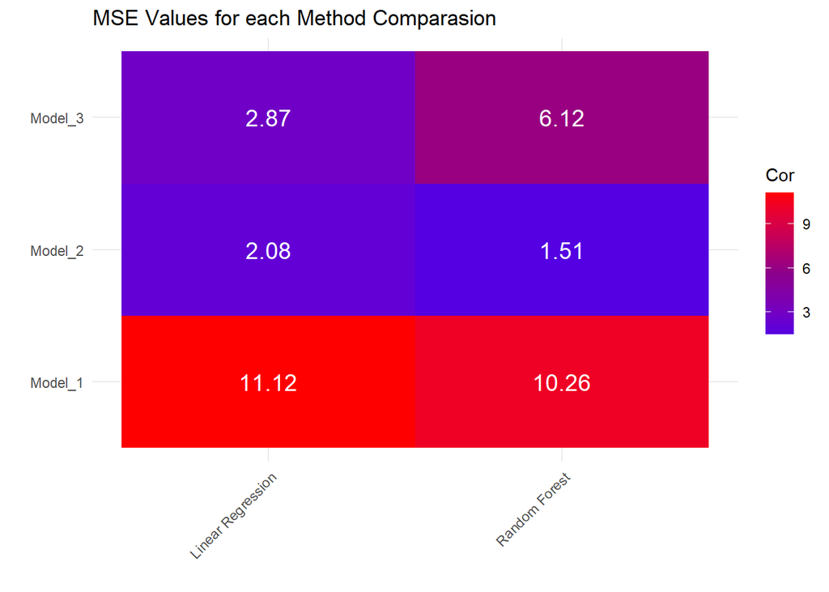

```r
my_table <- data.frame(
  Var1 = c("Random Forest", "Random Forest", "Random Forest","Linear Regression", "Linear Regression", "Linear Regression"),
  Var2 = c("Model_3", "Model_2", "Model_1","Model_3", "Model_2", "Model_1"),
  Cor = c(rf_mse_3, rf_mse_2, rf_mse_1,lr_mse_3,lr_mse_2,lr_mse_1)
)
mp = mean(my_table$Cor)
ggplot(data = my_table, aes(x = Var1, y = Var2, fill = Cor)) +
  geom_tile() +
  scale_fill_gradient2(low = "blue", high = "red", mid = "darkmagenta", midpoint = mp) +
  geom_text(aes(label=round(Cor,2)),color="white",size=5)+
  labs(x = "", y = "",title = "MSE Values for each Method Comparasion") +
  theme_minimal() +
  theme(axis.text.x = element_text(angle = 45, hjust = 1))
```

```r
me_rf=mean(my_table$Cor[1:3])
cat("In these 3 model comparisons, the average MSE value of Random Forest: \n", me_rf, "\n")
```

```
## In these 3 model comparisons, the average MSE value of Random Forest:
##  5.962457
```

```r
me_lr=mean(my_table$Cor[4:6])
cat("In these 3 model comparisons, the average MSE value of Linear Regression: \n", me_lr, "\n")
```

```
## In these 3 model comparisons, the average MSE value of Linear Regression:
##  5.356715
```